#### PCA analyis

```r
# Conducting a PCA of the transposed matrix
pca.clinical <- prcomp(tRNA[, c(1:as.numeric(ncol(tRNA)))], center = TRUE, scale = TRUE)
summary(pca.clinical)
```

```
## Importance of components:
##                            PC1      PC2      PC3      PC4      PC5      PC6
## Standard deviation     76.7748 68.79284 54.83260 49.55917 40.25594 36.40613
## Proportion of Variance  0.1071  0.08596  0.05461  0.04461  0.02944  0.02408
## Cumulative Proportion   0.1071  0.19303  0.24764  0.29226  0.32169  0.34577
##                             PC7     PC8      PC9     PC10     PC11     PC12
## Standard deviation     33.73784 31.3949 28.77220 26.83570 25.85641 24.84801
## Proportion of Variance  0.02068  0.0179  0.01504  0.01308  0.01214  0.01122
## Cumulative Proportion   0.36644  0.3844  0.39938  0.41246  0.42461  0.43582
##                            PC13     PC14     PC15     PC16     PC17     PC18
## Standard deviation     23.13294 22.74253 22.17559 20.81878 20.69815 19.74573
## Proportion of Variance  0.00972  0.00939  0.00893  0.00787  0.00778  0.00708
## Cumulative Proportion   0.44554  0.45494  0.46387  0.47174  0.47953  0.48661
##                            PC19     PC20    PC21     PC22     PC23     PC24
## Standard deviation     19.42670 19.12020 18.3321 17.97334 17.73598 17.51861
## Proportion of Variance  0.00686  0.00664  0.0061  0.00587  0.00571  0.00557
## Cumulative Proportion   0.49346  0.50010  0.5062  0.51208  0.51779  0.52336
##                            PC25    PC26     PC27     PC28     PC29     PC30
## Standard deviation     17.26456 16.9225 16.46165 16.34969 16.11357 15.72790
## Proportion of Variance  0.00541  0.0052  0.00492  0.00486  0.00472  0.00449
## Cumulative Proportion   0.52878  0.5340  0.53890  0.54376  0.54847  0.55297
##                            PC31     PC32     PC33     PC34    PC35     PC36
## Standard deviation     15.52448 15.37411 15.04981 14.76966 14.6539 14.57566
## Proportion of Variance  0.00438  0.00429  0.00411  0.00396  0.0039  0.00386
## Cumulative Proportion   0.55734  0.56164  0.56575  0.56971  0.5736  0.57747
##                            PC37     PC38     PC39     PC40     PC41     PC42
## Standard deviation     14.42270 14.18718 13.90411 13.75125 13.61898 13.49808
## Proportion of Variance  0.00378  0.00366  0.00351  0.00343  0.00337  0.00331
## Cumulative Proportion   0.58125  0.58491  0.58842  0.59186  0.59522  0.59853
##                            PC43     PC44     PC45     PC46     PC47     PC48
## Standard deviation     13.40084 13.24626 13.16265 13.03161 12.95868 12.90451
## Proportion of Variance  0.00326  0.00319  0.00315  0.00308  0.00305  0.00302
## Cumulative Proportion   0.60180  0.60498  0.60813  0.61121  0.61427  0.61729
##                            PC49     PC50     PC51     PC52     PC53     PC54
## Standard deviation     12.76140 12.48796 12.39820 12.32189 12.14651 12.11730
## Proportion of Variance  0.00296  0.00283  0.00279  0.00276  0.00268  0.00267
## Cumulative Proportion   0.62025  0.62308  0.62587  0.62863  0.63131  0.63398
##                            PC55    PC56     PC57     PC58    PC59     PC60
## Standard deviation     12.04252 11.9611 11.90586 11.87251 11.7282 11.59225
## Proportion of Variance  0.00263  0.0026  0.00257  0.00256  0.0025  0.00244
```

[output cut: 246 more lines]

```
## Standard deviation     3.71712 3.68813 3.68397 3.64951 3.63843 3.60414 3.59699
## Proportion of Variance 0.00025 0.00025 0.00025 0.00024 0.00024 0.00024 0.00024
## Cumulative Proportion  0.99525 0.99549 0.99574 0.99598 0.99622 0.99646 0.99669
##                          PC491   PC492   PC493   PC494   PC495   PC496   PC497
## Standard deviation     3.58202 3.56360 3.53267 3.50658 3.47370 3.43659 3.40931
## Proportion of Variance 0.00023 0.00023 0.00023 0.00022 0.00022 0.00021 0.00021
## Cumulative Proportion  0.99693 0.99716 0.99738 0.99761 0.99783 0.99804 0.99825
##                          PC498   PC499  PC500  PC501  PC502   PC503   PC504
## Standard deviation     3.39603 3.36534 3.3188 3.2916 3.2785 3.26009 3.24247
## Proportion of Variance 0.00021 0.00021 0.0002 0.0002 0.0002 0.00019 0.00019
## Cumulative Proportion  0.99846 0.99867 0.9989 0.9991 0.9993 0.99945 0.99964
##                          PC505   PC506     PC507
## Standard deviation     3.20594 3.05956 4.025e-13
## Proportion of Variance 0.00019 0.00017 0.000e+00
## Cumulative Proportion  0.99983 1.00000 1.000e+00
```

#### 90% of the signifiacant PCs

```r
# Attempting to find the 90% most significant PCs
amountOfPCs = 0
pcSum = 0

for(i in pca.clinical$sdev ) {
  if(i + pcSum > 0.9*sum(pca.clinical$sdev) ) {
    pcSum = pcSum + i
    amountOfPCs = amountOfPCs + 1
    break
  }
  pcSum = pcSum + i
  amountOfPCs = amountOfPCs + 1
}

amountOfPCs
```

```
## [1] 406
```

There are far too many PCs in order to complete a more effective assessment.

```r
componentMatrix <- cbind( clinical.dataset2$PATH_M_STAGE, clinical.dataset2$PATH_N_STAGE, clinical.dataset2$OS_STATUS, pca.clinical$x[,1:20])
colnames(componentMatrix)[1:3] <- c( "M_Stage", "N_Stage", "OS_Status")
componentMatrix <- as.data.frame(componentMatrix)
componentMatrix[,4:23] <- lapply(componentMatrix[,4:23], as.numeric) # Converting the matrix values of the PCs to be numeric
```

#### Creating various plots to graphically represent the proportions of variance.

```r
s <- summary(pca.clinical)

#ggbiplot(pca.clinical)
str(s)
```

```
## List of 6
##  $ sdev      : num [1:507] 76.8 68.8 54.8 49.6 40.3 ...
##  $ rotation  : num [1:55053, 1:507] -6.53e-05 -1.65e-04 2.65e-03 5.09e-03 6.15e-03 ...
##   ..- attr(*, "dimnames")=List of 2
##   .. ..$ : chr [1:55053] "ENSG00000000003" "ENSG00000000005" "ENSG00000000419" "ENSG00000000457" ...
##   .. ..$ : chr [1:507] "PC1" "PC2" "PC3" "PC4" ...
##  $ center    : Named num [1:55053] 3477.2 84.9 1490.2 785 234.1 ...
##   ..- attr(*, "names")= chr [1:55053] "ENSG00000000003" "ENSG00000000005" "ENSG00000000419" "ENSG00000000457" ...
##  $ scale     : Named num [1:55053] 2505 410 542 305 109 ...
##   ..- attr(*, "names")= chr [1:55053] "ENSG00000000003" "ENSG00000000005" "ENSG00000000419" "ENSG00000000457" ...
##  $ x         : num [1:507, 1:507] 15.4 13.9 -10.1 -32.8 -22.2 ...
##   ..- attr(*, "dimnames")=List of 2
##   .. ..$ : chr [1:507] "TCGA-A3-3382" "TCGA-CZ-5453" "TCGA-B0-5120" "TCGA-B0-5119" ...
##   .. ..$ : chr [1:507] "PC1" "PC2" "PC3" "PC4" ...
##  $ importance: num [1:3, 1:507] 76.775 0.107 0.107 68.793 0.086 ...
##   ..- attr(*, "dimnames")=List of 2
##   .. ..$ : chr [1:3] "Standard deviation" "Proportion of Variance" "Cumulative Proportion"
##   .. ..$ : chr [1:507] "PC1" "PC2" "PC3" "PC4" ...
##  - attr(*, "class")= chr "summary.prcomp"
```

```r
dev_std <- s$sdev
var_pr <- dev_std^2
var_pr[1:30]
```

```
##  [1] 5894.3770 4732.4549 3006.6135 2456.1115 1620.5408 1325.4063 1138.2421
##  [8]  985.6415  827.8392  720.1546  668.5538  617.4237  535.1327  517.2227
## [15]  491.7566  433.4215  428.4136  389.8938  377.3965  365.5819  336.0646
## [22]  323.0410  314.5650  306.9018  298.0649  286.3705  270.9859  267.3124
## [29]  259.6473  247.3669
```

```r
varex.propt <- var_pr/sum(var_pr)
varex.propt[1:30]
```

```
##  [1] 0.107067317 0.085961798 0.054613073 0.044613581 0.029436012 0.024075097
##  [7] 0.020675387 0.017903503 0.015037132 0.013081114 0.012143822 0.011215079
## [13] 0.009720318 0.009394996 0.008932421 0.007872804 0.007781839 0.007082153
## [19] 0.006855149 0.006640544 0.006104383 0.005867819 0.005713858 0.005574661
## [25] 0.005414145 0.005201724 0.004922274 0.004855547 0.004716314 0.004493249
```

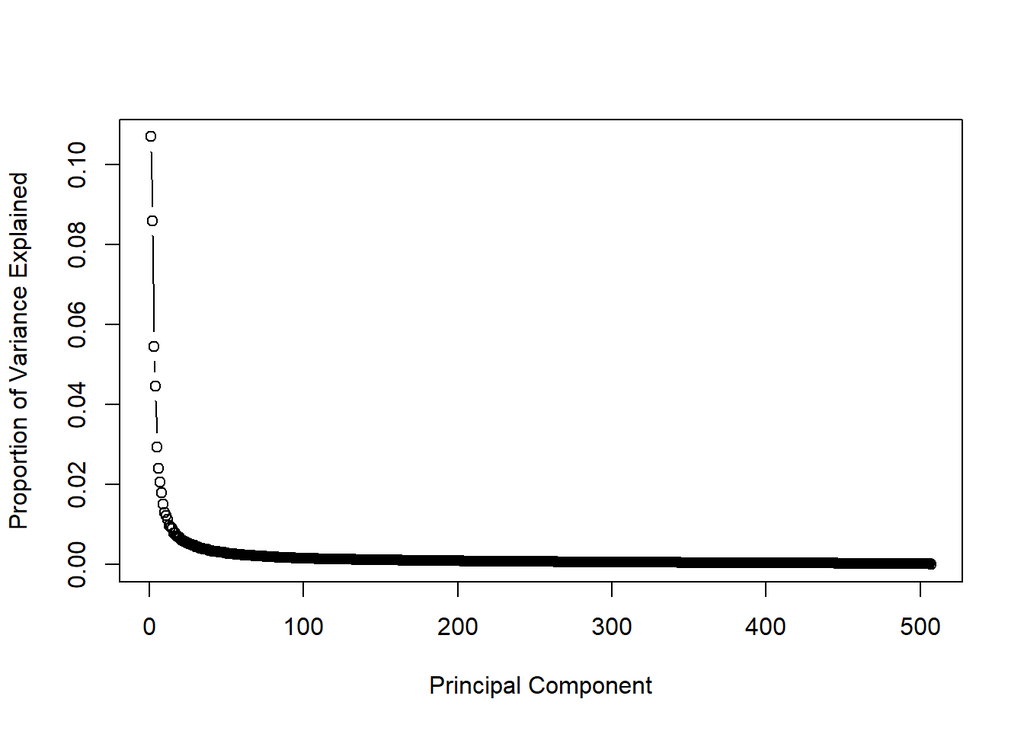

```r
#scree plot
plot(varex.propt, xlab = "Principal Component", ylab = "Proportion of Variance Explained", type = "b") #scree plot
```

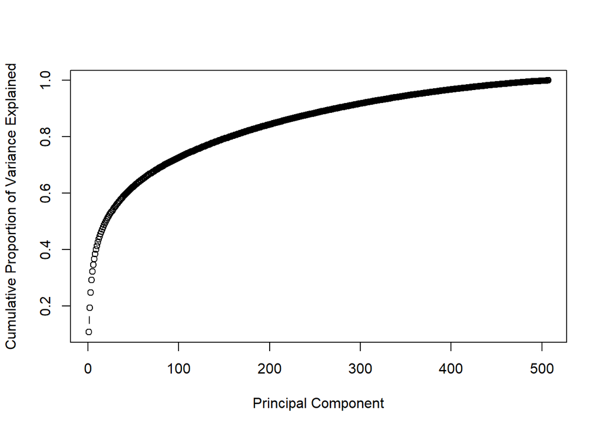

```r
plot(cumsum(varex.propt), xlab = "Principal Component", ylab = "Cumulative Proportion of Variance Explained", type = "b") #cumulative scree plot
```

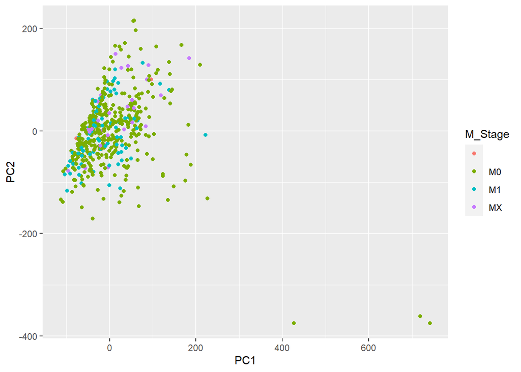

```r
pca_data <- as.data.frame(pca.clinical$x)
M_Stage <- factor(clinical.dataset2$PATH_M_STAGE)
ggplot(pca_data, aes(x=PC1, y=PC2)) + geom_point(aes(colour=M_Stage)) # Scatter Plot
```

```r
require(reshape2)
```

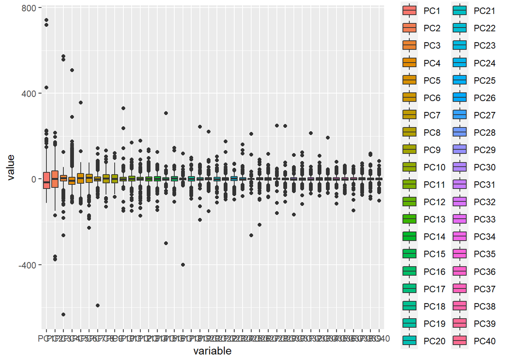

```r
dt <- as.data.frame(pca.clinical$x[,1:40])
ggplot(data = melt(dt), aes(x = variable, y=value))+ geom_boxplot(aes(fill=variable), xlab = "PCs") # Boxplot Comparison
```

First one has high variability suggesting significance. The further along the plot we go we can see that there is lower variance meaning there is little significance.

#### Initializing the Train and Test datasets

```r
kirc.dataset.train <- componentMatrix[sample(nrow(componentMatrix))[1:(nrow(componentMatrix)/2)],]
kirc.dataset.test <- componentMatrix[sample(nrow(componentMatrix))[(nrow(componentMatrix)/2):(nrow(componentMatrix))],]
```

#### Removing rows with MX from data to not skew prediction data

```r
kirc.dataset.test <- kirc.dataset.test[!(kirc.dataset.test$M_Stage=="MX"),]
kirc.dataset.test <- kirc.dataset.test[!(is.na(kirc.dataset.test$M_Stage) | kirc.dataset.test$M_Stage==""), ]

kirc.dataset.train <- kirc.dataset.train[!(kirc.dataset.train$M_Stage=="MX"),]
kirc.dataset.train <- kirc.dataset.train[!(is.na(kirc.dataset.train$M_Stage) | kirc.dataset.train$M_Stage==""), ]
```

#### Creating logistic regression analysis

```r
glm.fit <- glm(as.factor(OS_Status) ~., data = kirc.dataset.train, family = binomial)
summary(glm.fit)
```

```
##
## Call:
## glm(formula = as.factor(OS_Status) ~ ., family = binomial, data = kirc.dataset.train)
##
## Deviance Residuals:
##     Min       1Q   Median       3Q      Max
## -1.8303  -0.8231  -0.6058   0.6713   2.0171
##
## Coefficients:
##               Estimate Std. Error z value Pr(>|z|)
## (Intercept) -1.3975626  0.3784326  -3.693 0.000222 ***
## M_StageM1    2.5436525  0.5123127   4.965 6.87e-07 ***
## N_StageN1    2.5855902  1.2367965   2.091 0.036568 *
## N_StageNX    0.2534054  0.3370776   0.752 0.452188
## PC1         -0.0051645  0.0196481  -0.263 0.792666
## PC2          0.0035454  0.0125390   0.283 0.777367
## PC3         -0.0044830  0.0284804  -0.157 0.874923
## PC4         -0.0009038  0.0228339  -0.040 0.968427
## PC5         -0.0088414  0.0153871  -0.575 0.565564
## PC6          0.0049571  0.0276837   0.179 0.857889
## PC7         -0.0553040  0.1015044  -0.545 0.585861
## PC8          0.0124479  0.0147426   0.844 0.398476
## PC9         -0.0014436  0.0092241  -0.157 0.875633
## PC10        -0.0569281  0.0528660  -1.077 0.281553
## PC11         0.0011717  0.0255200   0.046 0.963381
## PC12         0.0534102  0.0654272   0.816 0.414311
## PC13         0.0365762  0.0296711   1.233 0.217680
## PC14         0.0193192  0.0239457   0.807 0.419787
## PC15         0.0733503  0.0539028   1.361 0.173581
## PC16        -0.0020309  0.0144502  -0.141 0.888230
## PC17         0.0279278  0.0552536   0.505 0.613245
## PC18        -0.0050861  0.0169768  -0.300 0.764489
## PC19        -0.0238003  0.0214526  -1.109 0.267241
## PC20        -0.0141222  0.0148085  -0.954 0.340257
## ---
## Signif. codes:  0 '***' 0.001 '**' 0.01 '*' 0.05 '.' 0.1 ' ' 1
##
## (Dispersion parameter for binomial family taken to be 1)
##
##     Null deviance: 307.81  on 237  degrees of freedom
## Residual deviance: 243.45  on 214  degrees of freedom
## AIC: 291.45
##
## Number of Fisher Scoring iterations: 9
```

#### Testing the accuracy, precision, and recall of the logistic Regression

```r
library(caret)
glm_pred_prob <- predict(glm.fit, kirc.dataset.test)
glm_pred <- ifelse(glm_pred_prob > 0.5, "M1", "M0")
d <- table(glm_pred, kirc.dataset.test$M_Stage) # Creating a table for the testing model
d
```

```
##
## glm_pred  M0  M1
##       M0 197   2
##       M1   7  32
```

```r
glm_pred_prob_train <- predict(glm.fit)
glm_pred_train <- ifelse(glm_pred_prob_train > 0.5, "M1", "M0")
table(glm_pred_train, kirc.dataset.train$M_Stage) # Creating a table for the training model
```

```
##
## glm_pred_train  M0  M1
##             M0 197   3
##             M1   5  33
```

```r
confMat <- confusionMatrix(as.factor(glm_pred), as.factor(kirc.dataset.test$M_Stage), positive = "M1") # Creating a confusion matrix to test regression.
confMat
```

```
## Confusion Matrix and Statistics
##
##           Reference
## Prediction  M0  M1
##         M0 197   2
##         M1   7  32
##
##                Accuracy : 0.9622
##                  95% CI : (0.9294, 0.9826)
##     No Information Rate : 0.8571
##     P-Value [Acc > NIR] : 8.673e-08
##
##                   Kappa : 0.8545
##
##  Mcnemar's Test P-Value : 0.1824
##
##             Sensitivity : 0.9412
##             Specificity : 0.9657
##          Pos Pred Value : 0.8205
##          Neg Pred Value : 0.9899
##              Prevalence : 0.1429
##          Detection Rate : 0.1345
##    Detection Prevalence : 0.1639
##       Balanced Accuracy : 0.9534
##
##        'Positive' Class : M1
##
```

```r
##Accuracy, Precision, and Recall defined by functions below for the Test set
print(paste0("Accuracy for the Test set: ", confMat$overall['Accuracy']))
```

```
## [1] "Accuracy for the Test set: 0.96218487394958"
```

#### Creating a plot to represent the comparison between True and False Positive Rates of the M model

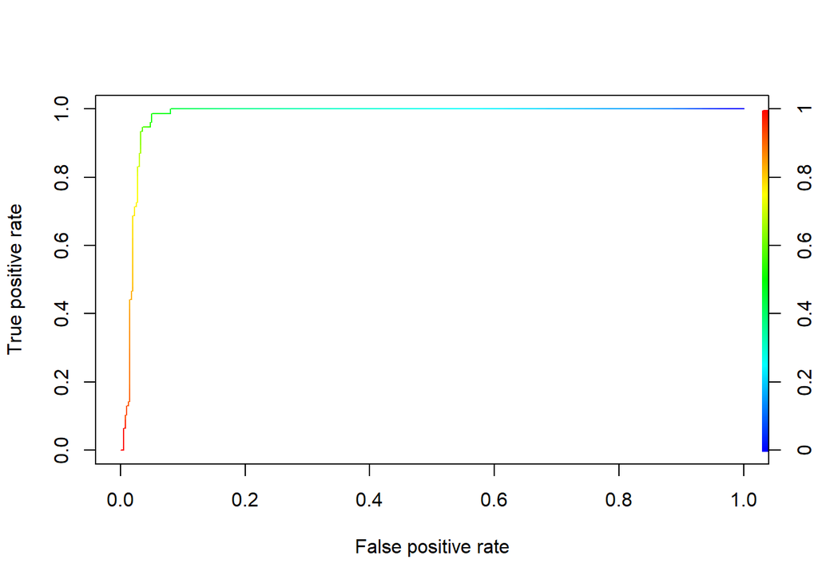

```r
library(ROCR)

componentMatrixMX <- componentMatrix[!(componentMatrix$M_Stage=="MX"),]
componentMatrixMX <- componentMatrixMX[!(is.na(componentMatrixMX$M_Stage) | componentMatrixMX$M_Stage==""), ]

pred.prob <- predict(glm.fit, componentMatrixMX, type="response")
predict <- prediction(pred.prob, componentMatrixMX$M_Stage, label.ordering=c("M0","M1"))
perform <- performance(predict,"tpr","fpr")
plot(perform,colorize=TRUE)
```

The ROC curve for our metastasis prediction model tells us that our model demonstrates high separability of the data due to the sharp high AUROC, with an AUC near 0.95. The model has high discrimination capacity to distinguish between positive class and negative class.

#### Creating a logistic regression model for the N Stage

```r
## Reinitialize training and test data sets in case rows with MX that were deleted included a
## working N value

kirc.dataset.train <- componentMatrix[sample(nrow(componentMatrix))[1:(nrow(componentMatrix)/2)],]
kirc.dataset.test <- componentMatrix[sample(nrow(componentMatrix))[(nrow(componentMatrix)/2):(nrow(componentMatrix))],]

#NX

kirc.dataset.test <- kirc.dataset.test[!(kirc.dataset.test$N_Stage=="NX"),]
kirc.dataset.test <- kirc.dataset.test[!(is.na(kirc.dataset.test$N_Stage) | kirc.dataset.test$N_Stage==""), ]

kirc.dataset.train <- kirc.dataset.train[!(kirc.dataset.train$N_Stage=="NX"),]
kirc.dataset.train <- kirc.dataset.train[!(is.na(kirc.dataset.train$N_Stage) | kirc.dataset.train$N_Stage==""), ]


glm.fit <- glm(as.factor(OS_Status) ~., data = kirc.dataset.train, family = binomial)
summary(glm.fit)
```

```
##
## Call:
## glm(formula = as.factor(OS_Status) ~ ., family = binomial, data = kirc.dataset.train)
##
## Deviance Residuals:
##     Min       1Q   Median       3Q      Max
## -2.0982  -0.6780  -0.4461   0.5508   2.1912
##
## Coefficients:
##              Estimate Std. Error z value Pr(>|z|)
## (Intercept) -1.790871   0.475859  -3.763 0.000168 ***
## M_StageM1    2.923223   0.702306   4.162 3.15e-05 ***
## M_StageMX    2.550732   1.828357   1.395 0.162987
## N_StageN1    0.074824   1.209268   0.062 0.950662
## PC1         -0.029610   0.019576  -1.513 0.130381
## PC2          0.023948   0.015653   1.530 0.126035
## PC3         -0.032785   0.030487  -1.075 0.282198
## PC4         -0.008708   0.017178  -0.507 0.612196
## PC5         -0.033345   0.021199  -1.573 0.115723
## PC6          0.027830   0.023855   1.167 0.243361
## PC7         -0.025774   0.026306  -0.980 0.327204
## PC8          0.022957   0.016723   1.373 0.169825
## PC9         -0.012475   0.013425  -0.929 0.352769
## PC10        -0.030730   0.038656  -0.795 0.426628
## PC11         0.018129   0.023709   0.765 0.444501
## PC12         0.034133   0.027135   1.258 0.208439
## PC13         0.031878   0.026822   1.188 0.234648
## PC14         0.038216   0.044287   0.863 0.388176
## PC15         0.153268   0.098307   1.559 0.118978
## PC16         0.015921   0.021939   0.726 0.468034
## PC17         0.010061   0.107167   0.094 0.925204
## PC18         0.020489   0.023513   0.871 0.383549
## PC19        -0.059245   0.048992  -1.209 0.226557
## PC20        -0.050552   0.040528  -1.247 0.212268
## ---
## Signif. codes:  0 '***' 0.001 '**' 0.01 '*' 0.05 '.' 0.1 ' ' 1
##
## (Dispersion parameter for binomial family taken to be 1)
##
##     Null deviance: 150.29  on 116  degrees of freedom
## Residual deviance: 100.27  on  93  degrees of freedom
## AIC: 148.27
##
## Number of Fisher Scoring iterations: 8
```

#### Creating confusion matrix to test the accuracy, precision, and recall of the N Stage model.

```r
glm_pred_prob <- predict(glm.fit, kirc.dataset.test)
glm_pred <- ifelse(glm_pred_prob > 0.5, "N1", "N0")
d <- table(glm_pred, kirc.dataset.test$N_Stage)
d
```

```
##
## glm_pred N0 N1
##       N0 93  6
##       N1 24  3
```

```r
glm_pred_prob_train <- predict(glm.fit)
glm_pred_train <- ifelse(glm_pred_prob_train > 0.5, "N1", "N0")
table(glm_pred_train, kirc.dataset.train$N_Stage)
```

```
##
## glm_pred_train N0 N1
##             N0 88  2
##             N1 24  3
```

```r
confMat2 <- confusionMatrix(as.factor(glm_pred), as.factor(kirc.dataset.test$N_Stage), positive = "N1")
confMat2
```

```
## Confusion Matrix and Statistics
##
##           Reference
## Prediction N0 N1
##         N0 93  6
##         N1 24  3
##
##                Accuracy : 0.7619
##                  95% CI : (0.6779, 0.8332)
##     No Information Rate : 0.9286
##     P-Value [Acc > NIR] : 1.000000
##
##                   Kappa : 0.0667
##
##  Mcnemar's Test P-Value : 0.001911
##
##             Sensitivity : 0.33333
##             Specificity : 0.79487
##          Pos Pred Value : 0.11111
##          Neg Pred Value : 0.93939
##              Prevalence : 0.07143
##          Detection Rate : 0.02381
##    Detection Prevalence : 0.21429
##       Balanced Accuracy : 0.56410
##
##        'Positive' Class : N1
##
```

```r
##Accuracy, Precision, and Recall defined by functions below for the Test set
print(paste0("Accuracy for the Test set: ", confMat2$overall['Accuracy']))
```

```
## [1] "Accuracy for the Test set: 0.761904761904762"
```

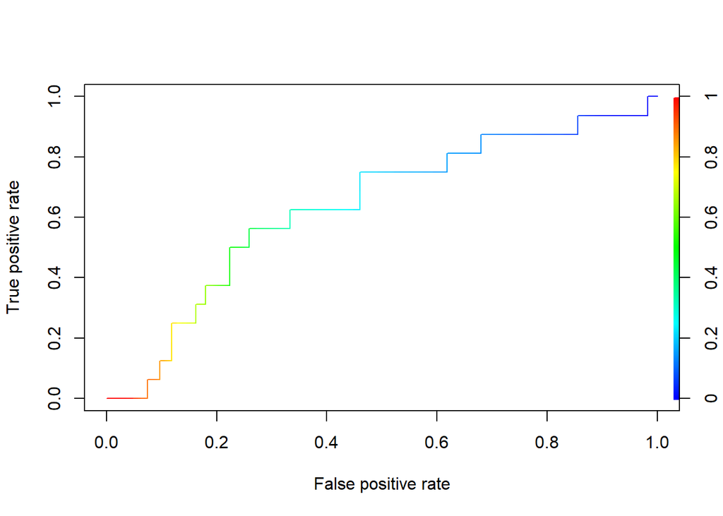

```r
componentMatrixNX <- componentMatrix[!(componentMatrix$N_Stage=="NX"),]
componentMatrixNX <- componentMatrixNX[!(is.na(componentMatrixNX$N_Stage) | componentMatrixNX$N_Stage==""), ]

pred.prob <- predict(glm.fit, componentMatrixNX, type="response")
predict <- prediction(pred.prob, componentMatrixNX$N_Stage, label.ordering=c("N0","N1"))
perform <- performance(predict,"tpr","fpr")
plot(perform,colorize=TRUE)
```